# Tugas Praktikum 2 MPDW

G1401211066_Oktavia Galih Pratiwi

2023-09-10

## Library

```r
library(dplyr)
library(TTR)
library(forecast)
library(lmtest) #uji formal pendeteksian autokorelasi
library(orcutt) #membuat model regresi Cochrane-Orcutt
library(HoRM) #membuat model regresi Hildreth-Lu
```

```r
library(corrplot)
library(knitr)
library(ggplot2)
library(rio)
library(olsrr)
library(GGally)
```

## Data Wind Power Forecasting

Data yang digunakan adalah Wind Power Forecasting. Data tersebut berisikan fitur cuaca, turbin dan rotor yang dicatat dari Januari 2018 hingga Maret 2020. Pembacaan dicatat dengan interval 10 menit. Berikut adalah informasi data yang digunakan untuk analisis.

```r
data_wind <- data.frame(
  Kode = c("Y", "X1", "X2", "X3", "X4", "X5", "X6"),
  Variabel = c("ActivePower", "AmbientTemperature", "BearingShaftTemperature",
                "GearboxBearingTemperature", "GeneratorRPM", "MainBoxTemperature",
                "ReactivePower")
)
data_wind
```

```
##   Kode                  Variabel
## 1    Y               ActivePower
## 2   X1        AmbientTemperature
## 3   X2   BearingShaftTemperature
## 4   X3 GearboxBearingTemperature
## 5   X4              GeneratorRPM
## 6   X5        MainBoxTemperature
## 7   X6             ReactivePower
```

## Import Data

Data yang digunakan pada analisis ini adalah 100 periode teratas

```r
data_wind<- import("https://raw.githubusercontent.com/oktaviagalihpratiwi/praktikum-mpdwokta/main/Pertemuan%202/data_wind.xlsx")
data_wind <- data_wind %>% slice(1:100)
View(data_wind)
str(data_wind)
```

```
## 'data.frame':    100 obs. of  8 variables:
##  $ Tanggal                  : POSIXct, format: "2018-08-17 23:20:00" "2018-08-17 23:30:00" ...
##  $ ActivePower              : num  1719 1721 1721 1737 1721 ...
##  $ AmbientTemperature       : num  27.7 27.6 27.5 27.3 27.2 ...
##  $ BearingShaftTemperature  : num  48 48 48.1 48.3 48.3 ...
##  $ GearboxBearingTemperature: num  76.8 76.7 76.6 76.4 76.3 ...
##  $ GeneratorRPM             : num  1756 1753 1751 1749 1761 ...
##  $ MainBoxTemperature       : num  40.9 40.8 40.7 40.6 40.6 ...
##  $ ReactivePower            : num  0.715 -0.272 1.128 0.724 -0.164 ...
```

## Eksplorasi Data

```r
#Membentuk objek time series
data.ts<-ts(data_wind$ActivePower)
data.ts
```

```
## Time Series:
## Start = 1
## End = 100
## Frequency = 1
##   [1] 1718.924 1721.001 1720.742 1736.691 1720.978 1719.472 1722.736 1717.741
##   [9] 1728.868 1715.225 1722.256 1714.931 1719.472 1717.136 1723.110 1721.712
##  [17] 1715.552 1712.580 1711.824 1718.872 1720.545 1722.109 1717.060 1719.017
##  [25] 1720.159 1720.637 1721.667 1727.323 1713.830 1719.463 1715.826 1715.584
##  [33] 1722.583 1717.432 1716.685 1716.460 1720.134 1716.843 1706.703 1638.461
##  [41] 1657.418 1425.277 1293.461 1441.504 1636.420 1718.011 1702.189 1701.617
##  [49] 1690.966 1510.414 1657.956 1434.233 1397.724 1354.203 1037.324 1100.833
##  [57] 1457.432 1444.738 1541.215 1671.396 1633.737 1427.501 1660.105 1697.301
##  [65] 1571.998 1702.562 1717.856 1714.270 1724.982 1728.056 1717.576 1722.059
##  [73] 1723.456 1731.036 1720.235 1723.125 1486.309 1712.040 1734.879 1728.084
##  [81] 1715.924 1730.648 1724.170 1701.516 1733.888 1723.414 1709.755 1721.784
##  [89] 1720.291 1724.051 1719.625 1720.821 1717.311 1730.938 1714.128 1727.727
##  [97] 1717.928 1722.148 1716.931 1723.246
```

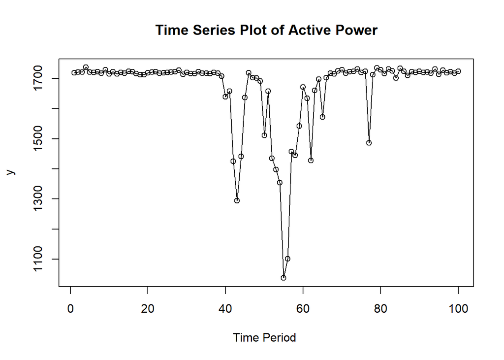

```r
#Membuat plot time series
ts.plot(data.ts, xlab="Time Period ", ylab="y", main= "Time Series Plot of Active Power")
points(data.ts)
```

###Plot Korelasi

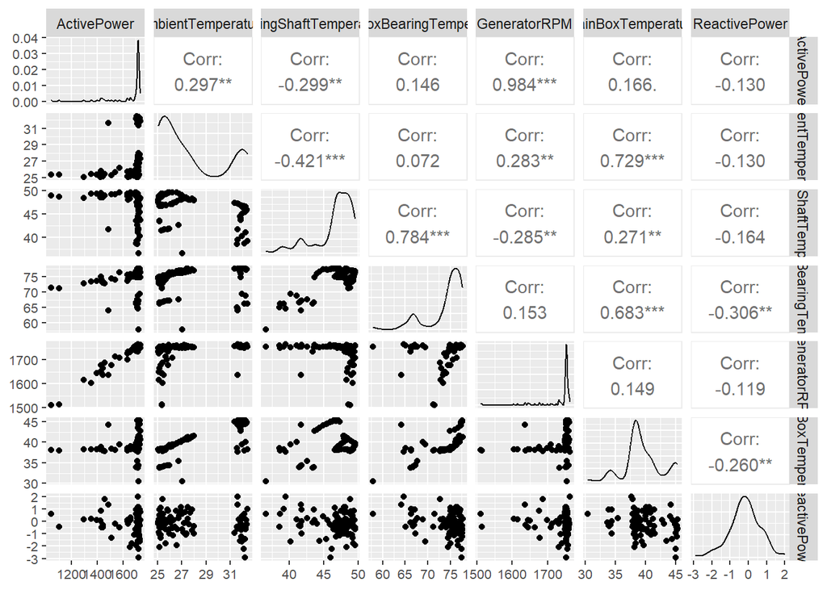

```r
#Menghasilkan plot ggpairs
plot <- ggpairs(data_wind[sapply(data_wind, is.numeric)])

#Mengatur ukuran font pada semua elemen
plot <- plot + theme(
  axis.text = element_text(size = 8),
  axis.title = element_text(size = 8),
  legend.text = element_text(size = 8)
)

#Tampilkan gambar
print(plot)
```

Korelasi tertinggi berada pada variabel X4 (GeneratorRPM) dan Y (ActivePower)

## Model Awal Regresi

```r
#Pembuatan Model Awal Regresi
Y <- data_wind$ActivePower
X1 <- data_wind$AmbientTemperature
X2 <- data_wind$BearingShaftTemperature
X3 <- data_wind$GearboxBearingTemperature
X4 <- data_wind$GeneratorRPM
X5 <- data_wind$MainBoxTemperature
X6 <- data_wind$ReactivePower
data_wind <- cbind(Y,X1,X2,X3,X4,X5,X6)
data_wind <- data.frame(data_wind)
model<- lm(Y ~ X1 + X2 + X3 + X4 + X5 + X6 , data = data_wind)
summary(model)
```

```
##
## Call:
## lm(formula = Y ~ X1 + X2 + X3 + X4 + X5 + X6, data = data_wind)
##
## Residuals:
##     Min      1Q  Median      3Q     Max
## -68.967  -7.346  -0.258   9.375  77.785
##
## Coefficients:
##               Estimate Std. Error t value Pr(>|t|)
## (Intercept) -2605.2007   162.7698 -16.005  < 2e-16 ***
## X1            -11.9964     3.7241  -3.221  0.00176 **
## X2             -7.4402     3.0037  -2.477  0.01506 *
## X3             -1.4997     2.2385  -0.670  0.50455
## X4              2.6468     0.0752  35.199  < 2e-16 ***
## X5             11.7440     3.6109   3.252  0.00160 **
## X6             -2.6518     2.7925  -0.950  0.34477
## ---
## Signif. codes:  0 '***' 0.001 '**' 0.01 '*' 0.05 '.' 0.1 ' ' 1
##
## Residual standard error: 22.2 on 93 degrees of freedom
## Multiple R-squared:  0.9721, Adjusted R-squared:  0.9703
## F-statistic: 539.5 on 6 and 93 DF,  p-value: < 2.2e-16
```

Hasil model awal regresi di atas menunjukkan bahwa terdapat 4 variabel penjelas yang berpengaruh secara signifikan terhadap variabel respon, yaitu Ambient Temperature (X1), Bearing Shaft Temperature (X2), GeneratorPRM (X4), dan Main Box Temperature (X5) dengan Koefisien Determinasi (Multiple R-squared) sebesar 97.21%. Untuk analisis selanjutnya, variabel penjelas yang digunakan adalah X1, X2, X4, dan X5.

```r
modelterbaik<- lm(Y ~ X1 + X2 + X4 + X5 , data = data_wind)
summary(modelterbaik)
```

```
##
## Call:
## lm(formula = Y ~ X1 + X2 + X4 + X5, data = data_wind)
##
## Residuals:
##     Min      1Q  Median      3Q     Max
## -71.837  -7.399  -1.050   8.366  76.631
##
## Coefficients:
##               Estimate Std. Error t value Pr(>|t|)
## (Intercept) -2.585e+03  1.471e+02 -17.578  < 2e-16 ***
## X1          -1.133e+01  3.615e+00  -3.135 0.002290 **
## X2          -8.447e+00  2.413e+00  -3.500 0.000710 ***
## X4           2.617e+00  5.172e-02  50.595  < 2e-16 ***
## X5           1.050e+01  3.048e+00   3.445 0.000853 ***
## ---
## Signif. codes:  0 '***' 0.001 '**' 0.01 '*' 0.05 '.' 0.1 ' ' 1
##
## Residual standard error: 22.11 on 95 degrees of freedom
## Multiple R-squared:  0.9717, Adjusted R-squared:  0.9705
## F-statistic: 815.9 on 4 and 95 DF,  p-value: < 2.2e-16
```

## Uji Multikolinearitas

Jika VIF > 10, ini menunjukkan bahwa variabel independen tersebut memiliki tingkat multikolinearitas yang tinggi dengan variabel lain dalam model. Artinya, variabel tersebut sangat berkorelasi dengan satu atau lebih variabel lainnya, yang dapat menyebabkan masalah dalam interpretasi hasil regresi.

```r
car::vif(modelterbaik)
```

```
##       X1       X2       X4       X5
## 18.94969 10.13287  1.20575 17.28277
```

```r
modelterbaik <- lm(Y ~ X2 + X4 + X5 , data = data_wind)
car::vif(modelterbaik)
```

```
##       X2       X4       X5
## 1.222459 1.158229 1.148949
```

## Pemeriksaan Asumsi Autokorelasi

### Uji Eksploratif

```r
#sisaan dan fitted value
sisaan<- residuals(modelterbaik)
sisaan
```

```
##            1            2            3            4            5            6
##  -0.60116593   8.32334453  12.67997764  34.38173168 -13.07277835  10.47540659
##            7            8            9           10           11           12
##  21.32455802   6.63060647  14.22758225  -3.51365145   5.86671511   6.67201548
##           13           14           15           16           17           18
##  10.55848081  -1.98660621   8.01035883   6.50765230  -0.51712362   8.21032031
##           19           20           21           22           23           24
##   1.54687088  -6.28444371 -13.31337460   5.46046265   2.27439732   3.61940082
##           25           26           27           28           29           30
##   2.63789997   0.35877562   7.04764475  18.95591554   0.76114976  -0.88036896
##           31           32           33           34           35           36
##  -0.45955398   2.69512764   8.95696959   4.06065367   4.07577694   2.56872584
##           37           38           39           40           41           42
##  12.17649641   9.97674420   7.24922112 -17.41713717   4.64679959 -10.86054022
##           43           44           45           46           47           48
## -49.60573972 -30.30071464   2.50163947  60.33908652  35.22804977  -6.32080330
##           49           50           51           52           53           54
## -17.14777946  -0.07395778  -6.55362329  11.33736094 -22.54476828  41.05716537
##           55           56           57           58           59           60
## -27.60017269  25.69275876 -74.34535581  42.95138378 -62.79820068  -3.05970161
##           61           62           63           64           65           66
##  67.98867865 -78.57948356   5.37622059 -18.56655477 -20.99211231 -21.12863644
##           67           68           69           70           71           72
##  16.72413594  -6.19792191   5.67398354   1.12528229  -2.72286853  -4.07033504
##           73           74           75           76           77           78
##  15.41933039  14.02696123  12.75962915  12.65427806  71.50197417 -27.51783334
##           79           80           81           82           83           84
##  -7.46157496   5.93395692  -4.47023623  13.12877471  -0.09498936 -12.47138639
##           85           86           87           88           89           90
##  12.09422884  -1.03658281 -18.08566947 -22.72449756  -1.69074473  -5.33091645
##           91           92           93           94           95           96
## -20.19502782  -8.34325706 -22.46293167   9.31495512 -21.62815793   3.90333264
##           97           98           99          100
##  -1.71145050  -4.49056322 -32.35766992  -6.08198574
```

```r
fitValue<- predict(modelterbaik)
fitValue
```

```
##        1        2        3        4        5        6        7        8
## 1719.525 1712.677 1708.062 1702.309 1734.051 1708.997 1701.412 1711.111
##        9       10       11       12       13       14       15       16
## 1714.640 1718.739 1716.390 1708.259 1708.913 1719.123 1715.100 1715.204
##       17       18       19       20       21       22       23       24
## 1716.069 1704.369 1710.277 1725.156 1733.858 1716.648 1714.786 1715.397
##       25       26       27       28       29       30       31       32
## 1717.521 1720.278 1714.620 1708.367 1713.069 1720.343 1716.285 1712.889
##       33       34       35       36       37       38       39       40
## 1713.626 1713.371 1712.609 1713.891 1707.958 1706.866 1699.454 1655.878
##       41       42       43       44       45       46       47       48
## 1652.771 1436.138 1343.067 1471.805 1633.918 1657.672 1666.961 1707.937
##       49       50       51       52       53       54       55       56
## 1708.113 1510.488 1664.510 1422.896 1420.269 1313.146 1064.924 1075.140
##       57       58       59       60       61       62       63       64
## 1531.777 1401.787 1604.014 1674.456 1565.748 1506.081 1654.729 1715.868
##       65       66       67       68       69       70       71       72
## 1592.990 1723.691 1701.132 1720.468 1719.308 1726.931 1720.299 1726.129
##       73       74       75       76       77       78       79       80
## 1708.037 1717.009 1707.475 1710.471 1414.807 1739.558 1742.340 1722.150
##       81       82       83       84       85       86       87       88
## 1720.394 1717.520 1724.265 1713.987 1721.793 1724.450 1727.840 1744.508
##       89       90       91       92       93       94       95       96
## 1721.982 1729.382 1739.820 1729.164 1739.774 1721.623 1735.756 1723.824
##       97       98       99      100
## 1719.640 1726.639 1749.288 1729.328
```

```r
length(sisaan)
```

```
## [1] 100
```

```r
length(fitValue)
```

```
## [1] 100
```

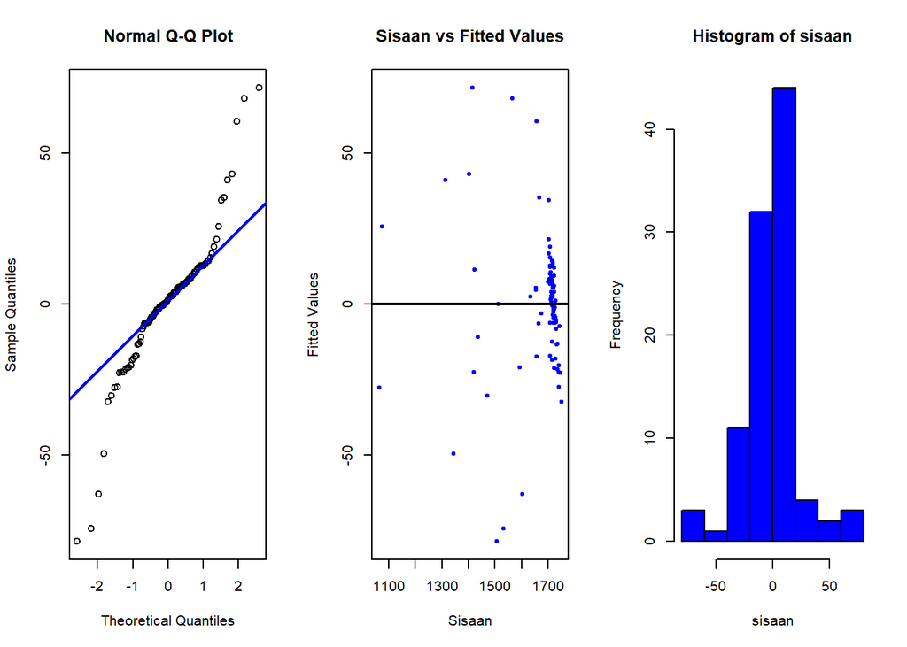

```r
### Diagnostik dengan eksploratif
par(mfrow = c(1,3))
qqnorm(sisaan)
qqline(sisaan, col = "blue", lwd = 2)
plot(fitValue, sisaan, col = "blue", pch = 20, xlab = "Sisaan", ylab = "Fitted Values", main = "Sisaan vs Fitted Values")
abline(a = 0, b = 0, lwd = 2)
hist(sisaan, col = "blue")
```

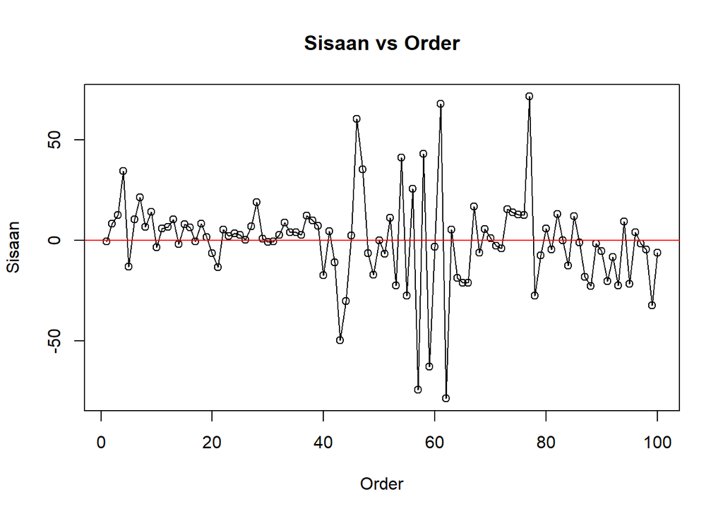

```r
plot(sisaan, type="o",
     ylab = "Sisaan", xlab = "Order", main = "Sisaan vs Order")
abline(h = 0, col='red')
```

Plot Sisaan vs Order menunjukkan pola naik turun sehingga keberadaan autokorelasi terindikasi. ###Uji ACF dan PACF

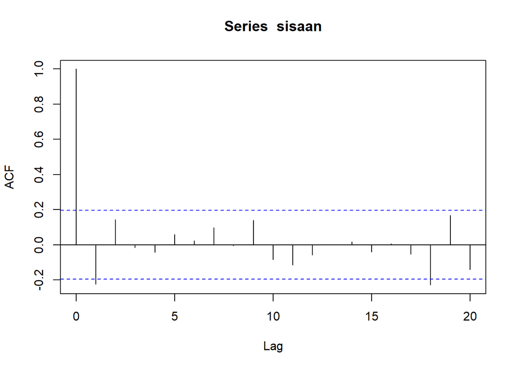

```r
acf(sisaan)
```

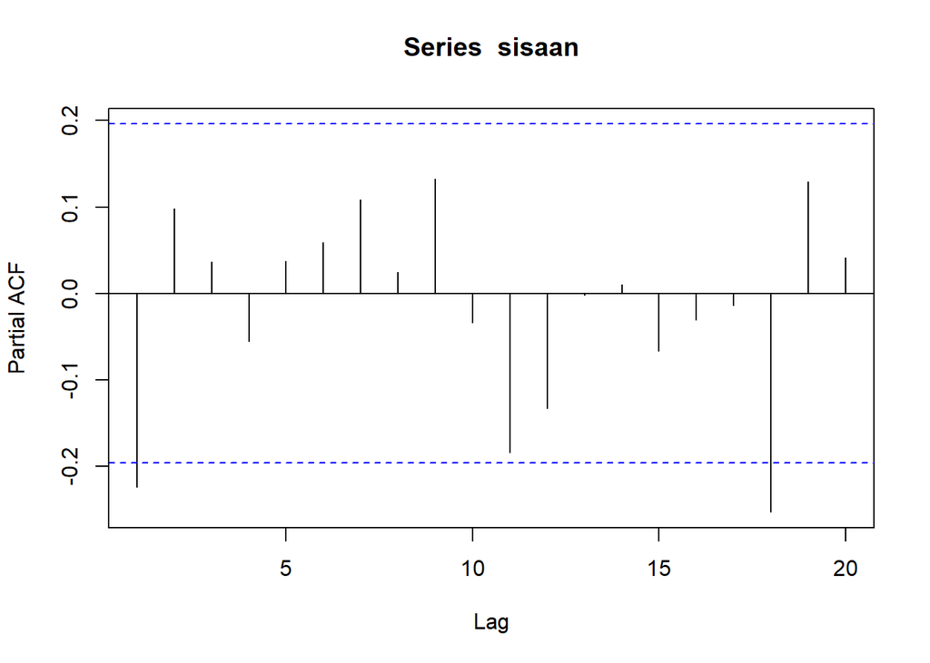

```r
pacf(sisaan)
```

Berdasarkan plot ACF dan PACF, terlihat bahwa terdapat titik di luar interval kepercayaan (garis biru). Hal ini menunjukkan adanya autokorelasi yang signifikan.

###Uji Formal: Durbin Watson H0: Tidak ada autokorelasi H1: Ada autokorelasi

```r
lmtest::dwtest(modelterbaik, alternative = 'two.sided')
```

```
##
##  Durbin-Watson test
##
## data:  modelterbaik
## DW = 2.4466, p-value = 0.03703
## alternative hypothesis: true autocorrelation is not 0
```

Berdasarkan hasil DW Test, didapatkan nilai $DW = 2.4466$ dan *p-value* = $0.03703$. Berdasarkan tabel Durbin-Watson diperoleh nilai $DL = 1.6131 $ dan $DU = 1.7364 $. Nilai DW yang didapatkan berada di antara 4-DL sampai 4. Artinya, berada di daerah autokorelasi negatif. Dengan nilai *p-value* < 0.05 juga dapat disimpulkan bahwa tolak H0 sehingga cukup bukti mengatakan adanya autokorelasi. Oleh karena itu, diperlukan penangan autokorelasi. Penanganan yang akan digunakan menggunakan dua metode, yaitu Cochrane-Orcutt dan Hildret-Lu.

## Penanganan Autokorelasi

### Metode Cochrane-Orcutt

Penanganan metode Cochrane-Orcutt dapat dilakukan dengan bantuan packages Orcutt pada aplikasi `R` maupun secara manual. Berikut ini ditampilkan cara menggunakan bantuan `library` *packages* `Orcutt`.

```r
#Penanganan Autokorelasi Cochrane-Orcutt
modelCO<-cochrane.orcutt(modelterbaik)
modelCO
```

```
## Cochrane-orcutt estimation for first order autocorrelation
##
## Call:
## lm(formula = Y ~ X2 + X4 + X5, data = data_wind)
##
##  number of interaction: 8
##  rho -0.25787
##
## Durbin-Watson statistic
## (original):    2.44657 , p-value: 9.815e-01
## (transformed): 1.95758 , p-value: 1.378e-01
##
##  coefficients:
##  (Intercept)           X2           X4           X5
## -2980.745062    -1.184565     2.689922     0.866220
```

```r
#Rho optimum
rho<- modelCO$rho
rho
```

```
## [1] -0.2578695
```

```r
#Transformasi Manual
Y.trans<- data_wind$Y[-1]-data_wind$Y[-100]*rho
X2.trans<- data_wind$X2[-1]-data_wind$X2[-100]*rho
X4.trans<- data_wind$X4[-1]-data_wind$X4[-100]*rho
X5.trans<- data_wind$X5[-1]-data_wind$X5[-100]*rho

modelCOmanual<- lm(Y.trans ~ X2.trans + X4.trans + X5.trans)
summary(modelCOmanual)
```

```
##
## Call:
## lm(formula = Y.trans ~ X2.trans + X4.trans + X5.trans)
##
## Residuals:
##     Min      1Q  Median      3Q     Max
## -64.750  -8.011   0.049   7.918  81.448
##
## Coefficients:
##               Estimate Std. Error t value Pr(>|t|)
## (Intercept) -3.749e+03  1.156e+02 -32.433   <2e-16 ***
## X2.trans    -1.185e+00  7.565e-01  -1.566    0.121
## X4.trans     2.690e+00  4.391e-02  61.257   <2e-16 ***
## X5.trans     8.662e-01  6.739e-01   1.285    0.202
## ---
## Signif. codes:  0 '***' 0.001 '**' 0.01 '*' 0.05 '.' 0.1 ' ' 1
##
## Residual standard error: 22.52 on 95 degrees of freedom
## Multiple R-squared:  0.9799, Adjusted R-squared:  0.9793
## F-statistic:  1544 on 3 and 95 DF,  p-value: < 2.2e-16
```

```r
#Mencari Penduga Koefisien Regresi setelah Transformasi ke Persamaan Awal
b0bintang <- modelCOmanual$coefficients[-(2:5)]
b0 <- b0bintang/(1-rho)
b1 <- modelCOmanual$coefficients[-1]
b0
```

```
## (Intercept)
##   -2980.745
```

```r
b1
```

```
##   X2.trans   X4.trans   X5.trans
## -1.1845645  2.6899218  0.8662205
```

```r
lmtest::dwtest(modelCO, alternative = 'two.sided')
```

```
##
##  Durbin-Watson test
##
## data:  modelCO
## DW = 1.9576, p-value = 0.2756
## alternative hypothesis: true autocorrelation is not 0
```

p-value (0.2756) > 0.05. Artinya tidak tolak H0. Maka, belum cukup bukti menyatakan bahwa ada autokorelasi dalam model.

## Metode Hildreth-Lu

Penanganan kedua adalah menggunakan metode Hildreth-Lu. Metode ini akan mencari nilai SSE terkecil dan dapat dicari secara manual maupun menggunakan packages. Jika menggunakan packages, gunakan `library` *packages* `HORM`.

### Penanganan Autokorelasi Hildreth lu

```r
#Penanganan Autokorelasi Hildreth lu
# Hildreth-Lu
hildreth.lu.func<- function(r, modelterbaik){
  x2 <- model.matrix(modelterbaik)[,2]
  x4 <- model.matrix(modelterbaik)[,3]
  x5 <- model.matrix(modelterbaik)[,4]

  y <- model.response(model.frame(modelterbaik))
  n <- length(y)
  t <- 2:n
  y <- y[t]-r*y[t-1]
  x2 <- x2[t]-r*x2[t-1]
  x4 <- x4[t]-r*x4[t-1]
  x5 <- x5[t]-r*x5[t-1]

  return(lm(y~x2+x4+x5))
}

#Pencariab rho yang meminimumkan SSE
r <- c(seq(-0.9,0.9, by= 0.1))
tab <- data.frame("rho" = r, "SSE" = sapply(r, function(i){deviance(hildreth.lu.func(i, modelterbaik))}))
round(tab, 4)
```

```
##     rho      SSE
## 1  -0.9 68971.26
## 2  -0.8 62935.18
## 3  -0.7 57942.24
## 4  -0.6 53988.56
## 5  -0.5 51067.05
## 6  -0.4 49165.88
## 7  -0.3 48266.33
## 8  -0.2 48339.93
## 9  -0.1 49345.13
## 10  0.0 51223.92
## 11  0.1 53900.13
## 12  0.2 57282.56
## 13  0.3 61277.75
## 14  0.4 65816.41
## 15  0.5 70890.45
## 16  0.6 76583.10
## 17  0.7 83063.77
## 18  0.8 90533.78
## 19  0.9 99171.75
```

```r
#Rho optimal di sekitar -0.3
rOpt <- seq(-0.4,-0.2, by= 0.001)
tabOpt <- data.frame("rho" = rOpt, "SSE" = sapply(rOpt, function(i){deviance(hildreth.lu.func(i, modelterbaik))}))
head(tabOpt[order(tabOpt$SSE),])
```

```
##        rho      SSE
## 143 -0.258 48180.77
## 144 -0.257 48180.81
## 142 -0.259 48180.83
## 145 -0.256 48180.94
## 141 -0.260 48180.99
## 146 -0.255 48181.17
```

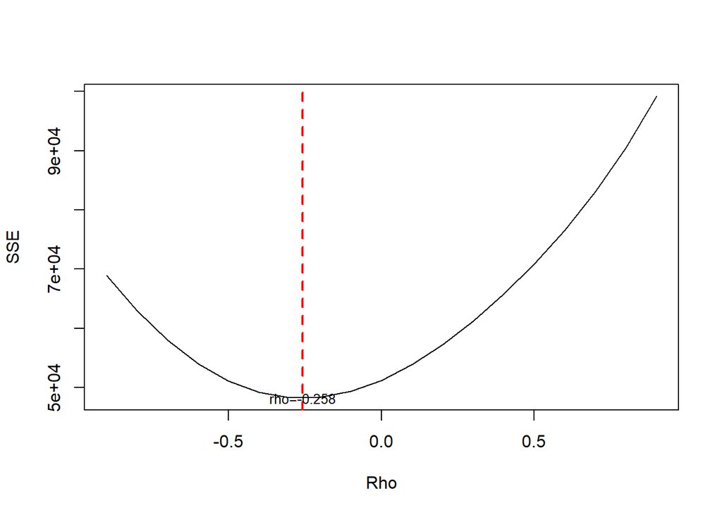

```r
#Grafik SSE optimum
par(mfrow = c(1,1))
plot(tab$SSE ~ tab$rho , type = "l", xlab = "Rho", ylab = "SSE")
abline(v = tabOpt[tabOpt$SSE==min(tabOpt$SSE),"rho"], lty = 2, col="red",lwd=2)
text(x=-0.258   , y=48180.77, labels = "rho=-0.258  ", cex = 0.8)
```

```r
#Model terbaik
modelHL <- hildreth.lu.func(-0.258, modelterbaik)
summary(modelHL)
```

```
##
## Call:
## lm(formula = y ~ x2 + x4 + x5)
##
## Residuals:
##     Min      1Q  Median      3Q     Max
## -64.745  -8.006   0.047   7.918  81.452
##
## Coefficients:
##               Estimate Std. Error t value Pr(>|t|)
## (Intercept) -3.750e+03  1.156e+02 -32.435   <2e-16 ***
## x2          -1.185e+00  7.564e-01  -1.566    0.121
## x4           2.690e+00  4.391e-02  61.262   <2e-16 ***
## x5           8.661e-01  6.739e-01   1.285    0.202
## ---
## Signif. codes:  0 '***' 0.001 '**' 0.01 '*' 0.05 '.' 0.1 ' ' 1
##
## Residual standard error: 22.52 on 95 degrees of freedom
## Multiple R-squared:  0.9799, Adjusted R-squared:  0.9793
## F-statistic:  1544 on 3 and 95 DF,  p-value: < 2.2e-16
```

#Deteksi autokorelasi

```r
dwtest(modelHL, , alternative = 'two.sided')
```

```
##
##  Durbin-Watson test
##
## data:  modelHL
## DW = 1.9573, p-value = 0.2772
## alternative hypothesis: true autocorrelation is not 0
```

```r
#Perbandingan
sseModelawal <- anova(modelterbaik)$`Sum Sq`[-(1:3)]
sseModelCO <- anova(modelCOmanual)$`Sum Sq`[-(1:3)]
sseModelHL <- anova(modelHL)$`Sum Sq`[-(1:3)]
mseModelawal <- sseModelawal/length(data_wind$Y)
mseModelCO <- sseModelCO/length(data_wind$Y)
mseModelHL <- sseModelHL/length(data_wind$Y)
akurasi <- matrix(c(sseModelawal,sseModelCO,sseModelHL,
                    mseModelawal,mseModelCO,mseModelHL),nrow=2,ncol=3,byrow = T)
colnames(akurasi) <- c("Model Awal", "Model Cochrane-Orcutt", "Model Hildreth-Lu")
row.names(akurasi) <- c("SSE","MSE")
akurasi
```

```
##     Model Awal Model Cochrane-Orcutt Model Hildreth-Lu
## SSE 51224.2885            48180.7714        48180.7722
## MSE   512.2429              481.8077          481.8077
```

```r
kable(akurasi)
```

|  | Model Awal | Model Cochrane-Orcutt | Model Hildreth-Lu |
| --- | --- | --- | --- |
| SSE | 51224.2885 | 48180.7714 | 48180.7722 |
| MSE | 512.2429 | 481.8077 | 481.8077 |